# Results

Loong Kuan

16 September 2016

## Original Data of 2 Dates

Load the satellite data set on the day *2013-05-05* and *2013-11-29*.

Data from *2013-05-05*.

```
##   band7 band5 band6 brightness band3      NDWI band4     NDVI band1 band2
## 1   260   253   305   512.5622   109  93.18996   124 342.1751    70    77
## 2   249   242   293   491.3013   105  95.32710   117 348.1894    68    75
## 3   258   243   299   502.1434   108 103.32103   121 335.1648    70    77
## 4   266   264   316   530.0330   113  89.65517   127 350.3836    73    80
## 5   268   290   338   559.5873   116  76.43312   128 387.5598    79    83
##   id_class
## 1    maize
## 2    maize
## 3    maize
## 4    maize
## 5    maize
```

Data from *2013-11-29*.

```
##       band7    band5    band6 brightness    band3      NDWI    band4     NDVI
## 1  75.39024 408.2927 144.9024   451.2738 76.17073 -476.1254 50.58537 779.5259
## 2 116.60976 290.8049 184.9024   383.8199 75.34146 -222.6210 79.26829 571.6074
## 3 140.29268 258.4390 206.6585   384.4472 77.46342 -111.3325 92.90243 471.1559
## 4 114.92683 354.6585 178.7805   428.3625 72.21951 -329.7060 66.68293 683.4732
## 5  76.78049 458.0976 145.0488   494.1166 63.78049 -519.0262 38.19512 846.0782
##      band1    band2 id_class
## 1 27.19512 34.12195    maize
## 2 33.51220 43.36585    maize
## 3 38.63415 49.95122    maize
## 4 33.51220 41.90244    maize
## 5 27.19512 33.12195    maize
```

Histogram of the data by attributes.

```
## [1] "Plots Obtained"
```

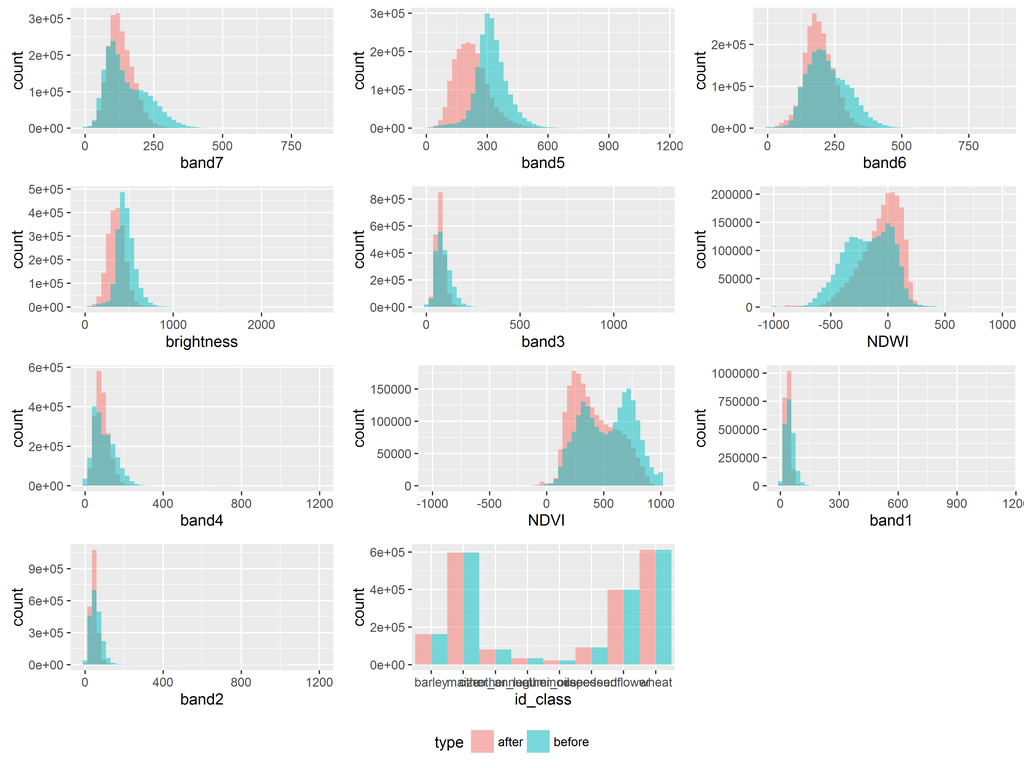

## Drift Results

The raw data of the results will be provided at the end of this document.

### Covariate Drift

The following is the results for a test of 1 Attribute. We can verify the correctness of the results by comparing them to the histograms of the attributes above.

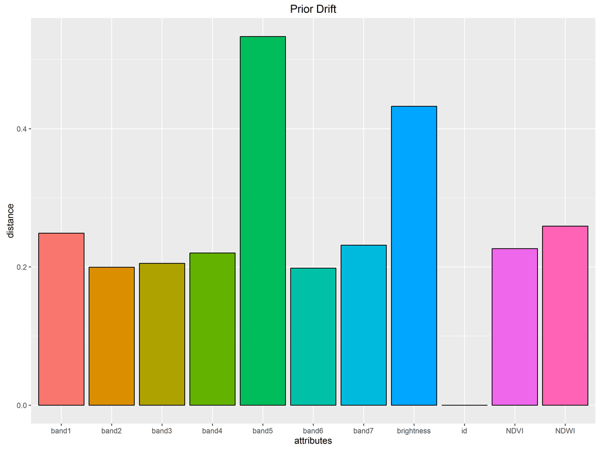

The following is the covariate results for 2 Attributes. This plot is just an exercise on how results from larger amounts of attributes might be visualised.

The plot is made by first constructing a “distance matrix” where the distance obtained for each pair of attribute is represneted.

```
##            [,1]      [,2]      [,3]      [,4]      [,5]      [,6]      [,7]
##  [1,] 0.0000000 0.2161702 0.2261602 0.5088277 0.5803029 0.2548694 1.0478926
##  [2,] 0.2161702 0.0000000 0.2365298 1.0197246 0.3012746 0.2742421 1.0578897
##  [3,] 0.2261602 0.2365298 0.0000000 0.8873757 0.5804967 0.2743355 1.0186302
##  [4,] 1.0176553 1.0197246 0.4436879 0.0000000 0.2325639 0.5439877 0.5430294
##  [5,] 0.2901514 0.3012746 0.5804967 0.2325639 0.0000000 0.3356936 0.5732034
##  [6,] 0.2548694 0.5484842 0.5486710 1.0879754 0.6713873 0.0000000 0.5663795
##  [7,] 0.5239463 1.0578897 0.5093151 0.5430294 0.5732034 1.1327591 0.0000000
##  [8,] 0.2883628 0.5523588 0.2962871 0.4416793 0.3312237 0.6273526 0.5106831
##  [9,] 0.3371023 0.6319340 0.6196457 0.9353582 0.2788898 0.3565237 0.9612521
## [10,] 0.9708315 0.4714653 0.5330292 0.5323806 0.4679662 0.8810754 1.0909714
## [11,] 1.0791872 0.5468371 0.5335880 1.0761008 1.0812093 1.1301014 0.5332722
##            [,8]      [,9]     [,10]     [,11]
##  [1,] 0.5767255 0.3371023 0.9708315 1.0791872
##  [2,] 0.5523588 0.6319340 0.4714653 1.0936743
##  [3,] 0.2962871 0.6196457 1.0660585 0.5335880
##  [4,] 0.8833586 0.9353582 1.0647613 1.0761008
##  [5,] 0.6624474 0.5577795 0.4679662 0.5406046
##  [6,] 0.3136763 0.7130474 0.8810754 0.5650507
##  [7,] 0.5106831 0.4806260 1.0909714 0.5332722
##  [8,] 0.0000000 0.2765198 1.0472711 1.0766309
##  [9,] 0.2765198 0.0000000 0.5196441 0.5417020
## [10,] 1.0472711 0.5196441 0.0000000 1.0811179
## [11,] 0.5383155 0.5417020 0.5405590 0.0000000
```

This matrix is then plotted using Multidimensional Scaling to visualise the distances in the matrix. The final plot will then plot attributes that have a higher dirft together further apart.

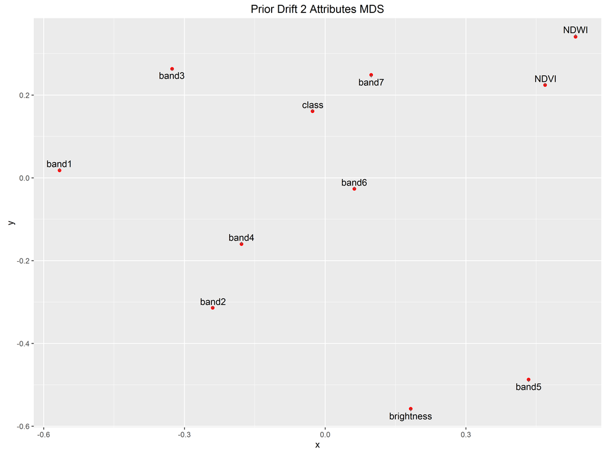

We can also plot the distance matrix as a heatmap to directly view the results. However this method only works with 2 attribute tests.

[interactive chart not shown]

Here is a heatmap for 3 attributes that contains the attribute with the highest variance in difference.

[interactive chart not shown]

### Conditioned Covaraites (Single Attributes)

[interactive chart not shown]

### Conditioned Covaraites (Pair Attributes)

```
## [1] "Plots obtained"
```

[interactive chart not shown]

### Posterior (1 Attribute)

[interactive chart not shown]

## Raw Data

https://github.com/LeeLoongKuan/DriftMapper/tree/master/data_out/martvard

## Raw Plots

https://github.com/LeeLoongKuan/DriftMapper/tree/master/DataAnalysisR/Plots